# State Vector Machine (SVM) Implementation

#### Visualizing Results

We now clip the weights as the test data contains only 20 data points. We extract the features from the test data and predict the values. We obtain the predictions and compare it with the actual values and print the accuracy of our model.

We remove elements 20 to 79 from the weight vectors so only 20 support vectors are retained, then reshape them to column vectors. Next, extract test data features, similarly to the training data, and reshape them to column vectors.

We then proceed to make predictions using the clipped and reshaped weight vectors and the test features.

Predictions are made based on the decision values. If a value in **y_pred** is greater than 1, append a 1 to the **predictions** list; otherwise, append -1.

For the accuracy score, we compare the predicted labels with the true labels from the test dataset, and print the result as a percentage.

```python
## Clip the weights
index = list(range(20,80))
w1 = np.delete(w1,index)
w2 = np.delete(w2,index)

w1 = w1.reshape(20,1)
w2 = w2.reshape(20,1)
## Extract the test data features
test_f1 = x_test[:,0]
test_f2 = x_test[:,1]

test_f1 = test_f1.reshape(20,1)
test_f2 = test_f2.reshape(20,1)
## Predict
y_pred = w1 * test_f1 + w2 * test_f2
predictions = []
for val in y_pred:
    if(val > 1):
        predictions.append(1)
    else:
        predictions.append(-1)

# Print accuracy
acc_text = f'Accuracy: {accuracy_score(y_test, predictions) * 100:.2f}%'
print(acc_text)
```

```
Accuracy: 100.00%
```

To better visualize the svm implementation and the results we can plot the data points and include the calculated decision boundary.

We reuse our previous scatter plot for the Setosa and Versicolor species using the Sepal Length and Petal Length. To this we generate points along the X-axis using **np.linspace** and calculate the corresponding Y-axis values based on the decision boundary.

The decision boundary is shown as a blue line with a solid **( - )** linestyle.

**x_decision_boundary** is an array of 20 equally spaced points between the minimum and maximum values of **train_f1**. The decision_boundary values are calculated based on the weights **w1** and **w2**.

$(w_1^2 + w_2^2)$ is the squared magnitude of the weight vector. We then get the square root of the squared magnitude, which gives us the Euclidean norm or the length of the weight vector. $(\sqrt{w_1^2 + w_2^2})$

$(\frac{1}{\sqrt{w_1^2 + w_2^2}})$ is the reciprocal of the length of the weight vector. In other words, a measure of the distance from the origin to the hyperplane defined by the weight vector. In other, other words, the margin.

We calculate the upper and lower margins by adding and subtracting the margin distance from the decision boundary, respectively.

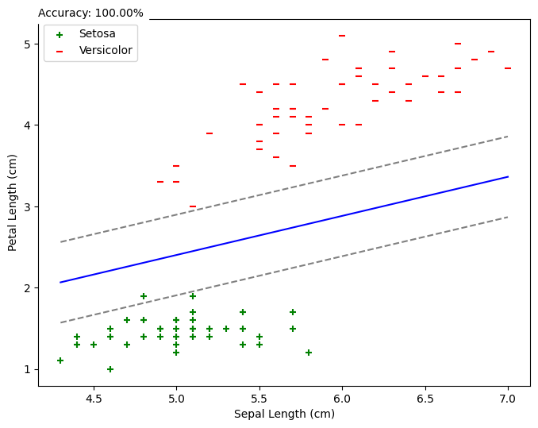

```python
# Plotting the decision boundary with automatic margin calculation
plt.figure(figsize=(8, 6))
plt.scatter(setosa_x, setosa_y, marker='+', color='green', label='Setosa')
plt.scatter(versicolor_x, versicolor_y, marker='_', color='red', label='Versicolor')
plt.xlabel('Sepal Length (cm)')  # X-axis label
plt.ylabel('Petal Length (cm)')  # Y-axis label
plt.legend()

# Calculate decision boundary
x_decision_boundary = np.linspace(min(train_f1), max(train_f1), 20)
y_decision_boundary = -(w1/w2) * x_decision_boundary.reshape(-1, 1)  # Reshape x_decision_boundary

# Calculate margin distance
margin_distance = 1 / np.sqrt(w1**2 + w2**2)

# Calculate margins
y_margin_upper = y_decision_boundary + margin_distance
y_margin_lower = y_decision_boundary - margin_distance

# Plot decision boundary
plt.plot(x_decision_boundary, y_decision_boundary, linestyle='-', color='blue', label='Decision Boundary')

# Plot margins
plt.plot(x_decision_boundary, y_margin_upper, linestyle='--', color='gray', label='Upper Margin')
plt.plot(x_decision_boundary, y_margin_lower, linestyle='--', color='gray', label='Lower Margin')

# Add accuracy percentage as text annotation
plt.text(plt.xlim()[0], plt.ylim()[1], acc_text, ha='left', va='bottom', backgroundcolor='white')
plt.show()
```